# Vector spatial features: Points, lines, and polygons in R

J. Camilo Fagua

February 2024

# **I. Objectives**

1. Learn the basic logic and construction of the vector spatial features (points, lines, polygons) in R.
2. Learn some of the basic operations with vector spatial features in R.
3. Understand the R logic to process vector spatial features.
4. Review some of the main R packages to process vector spatial feature in R.

# **II. Introduction**

This tutorial is focused on providing you the tools required to build, read, and project vector spatial feature in R. There are two main packages used by the R community to bring vector spatial feature data into R: 1) [sp](https://www.rdocumentation.org/packages/sp/versions/2.1-2) and [sf](https://r-spatial.github.io/sf/). In this tutorial, we will also use the package tidyverse. Let’s go to start.

The package sp is the mama-package of all vector spatial feature packages of R. sp revolutionized the spatial analysis in R when it was built. Team sp created a set of data classes that integrates the traditional objects of R (vector, data.frame, matrix, list, and others) with the vector spatial features: points, lines, and polygons. The package sf is considered an evolution of sp; however, sp is maintained in R since many packages were built using the sp architecture, including the sf package. The plan is that sf succeeds sp in the long term.

# **III. Some important definitions before the scripts**

**Simple features**: Simple feature refers to a formal standard (ISO 19125-1:2004) that describes how objects in the real world can be represented in computers, with emphasis on the spatial geometry of these objects (points, lines, polygons, pixels, raster). That is, a feature is thought of as a thing, or an object in the real world, such as a building or a tree. As with any other object, a feature often consists of other objects (features), that is, a set of features can form a single feature. A forest stand can be a feature, a forest can be a feature, a city can be a feature. A satellite image pixel can be a feature, a complete image can be a feature too (Pebesma and Bivand, 2023).

**Geometry**: Features (points, lines, polygons, pixels, raster) have a geometry describing where on Earth (or Cartesian plane) the feature is located, and they have attributes, which describe other properties. The geometry of a tree can be the delineation of its crown, of its stem, or the point indicating its center. Other properties may include its height, color, diameter at breast height at a particular date, and so on (Pebesma and Bivand, 2023).

**Dimensions** All vector geometries are composed of points. Points are coordinates in a 2-, 3- or 4-dimensional (even more) space. In addition to X and Y coordinates, there are two optional additional dimensions, Z coordinate to denote altitude, and M coordinate(s) to measure an extra variable(s).

**Coordinate Reference System - CRS**: CRS is a latitude-longitude projection model of the earth based on a geoid model.

**Geoid**: A geoid is an irregular-shaped model to accurately calculate locations on and under the earth’s surface.

**Geodetic datum**: Datum refers to the definition of Earth center-position in the geoid.

In this tutorial, we are going to star with the creation from scratch of spatial data using the traditional sp-package to later explain the creation from scratch of spatial data using sf.You need to make sure the following packages are installed and loaded into your RStudio session.

```r
# To clean environment
rm(list = ls(all.names = TRUE))
gc()
```

```
##          used (Mb) gc trigger (Mb) max used (Mb)
## Ncells 520352 27.8    1156527 61.8   660385 35.3
## Vcells 951536  7.3    8388608 64.0  1772588 13.6
```

```r
#To install packages
#install.packages("sp")
#install.packages("sf")
#install.packages("tidyverse")

library("sp")
library("sf")
library("tidyverse")
```

# **IV. Creating spatial objects from scratch using sp**

You can see the catalogue of object classes supported by sp by calling the function getClass().

```r
getClass("Spatial")
```

```
## Class "Spatial" [package "sp"]
##
## Slots:
##
## Name:         bbox proj4string
## Class:      matrix         CRS
##
## Known Subclasses:
## Class "SpatialPoints", directly
## Class "SpatialMultiPoints", directly
## Class "SpatialGrid", directly
## Class "SpatialLines", directly
## Class "SpatialPolygons", directly
## Class "SpatialPointsDataFrame", by class "SpatialPoints", distance 2
## Class "SpatialPixels", by class "SpatialPoints", distance 2
## Class "SpatialMultiPointsDataFrame", by class "SpatialMultiPoints", distance 2
## Class "SpatialGridDataFrame", by class "SpatialGrid", distance 2
## Class "SpatialLinesDataFrame", by class "SpatialLines", distance 2
## Class "SpatialPixelsDataFrame", by class "SpatialPoints", distance 3
## Class "SpatialPolygonsDataFrame", by class "SpatialPolygons", distance 2
```

The subclasses followed by DataFrame in the above catalogue, such as SpatialPointsDataFrame, include additional attributes in the form of a data.frame. For example, if you were working with a SpatialPolygon object, this object would only includes the spatial information required to plot the block group of polygons. With a SpatialPolygonDataFrame, in a single object, you have both the polygon data and additional data stored in a data.frame (think in the attribute tables of ArcGis or Qgis).

## **Spatial points**

We are going to start generating a set of 10 points on the unit square [0, 1] and [0, 1]. The function runif() creates random numbers that follow a uniform distribution while the function round() returns rounded values to the specified number of decimal places.

```r
xc = round(runif(10), 2)
yc = round(runif(10), 2)
xy = cbind(xc, yc)
xy
```

```
##         xc   yc
##  [1,] 0.61 0.70
##  [2,] 0.39 0.73
##  [3,] 0.91 0.56
##  [4,] 0.35 0.13
##  [5,] 0.78 0.45
##  [6,] 0.26 0.28
##  [7,] 0.67 0.82
##  [8,] 0.38 0.46
##  [9,] 0.71 0.93
## [10,] 0.08 0.45
```

```r
class(xy)
```

```
## [1] "matrix" "array"
```

The matrix xy can be converted into a SpatialPoints object by the function SpatialPoints. You can observe the change of the object type by using the function class().

```r
xy.sp = SpatialPoints(xy)
class(xy.sp)
```

```
## [1] "SpatialPoints"
## attr(,"package")
## [1] "sp"
```

```r
xy.sp
```

```
## SpatialPoints:
##         xc   yc
##  [1,] 0.61 0.70
##  [2,] 0.39 0.73
##  [3,] 0.91 0.56
##  [4,] 0.35 0.13
##  [5,] 0.78 0.45
##  [6,] 0.26 0.28
##  [7,] 0.67 0.82
##  [8,] 0.38 0.46
##  [9,] 0.71 0.93
## [10,] 0.08 0.45
## Coordinate Reference System (CRS) arguments: NA
```

Although the Coordinate Reference System (CRS) argument is NA (Not-Available), we can plot and retrieve the coordinates of xy.sp because this is a spatial object. Observe that xy.cc is a matrix.

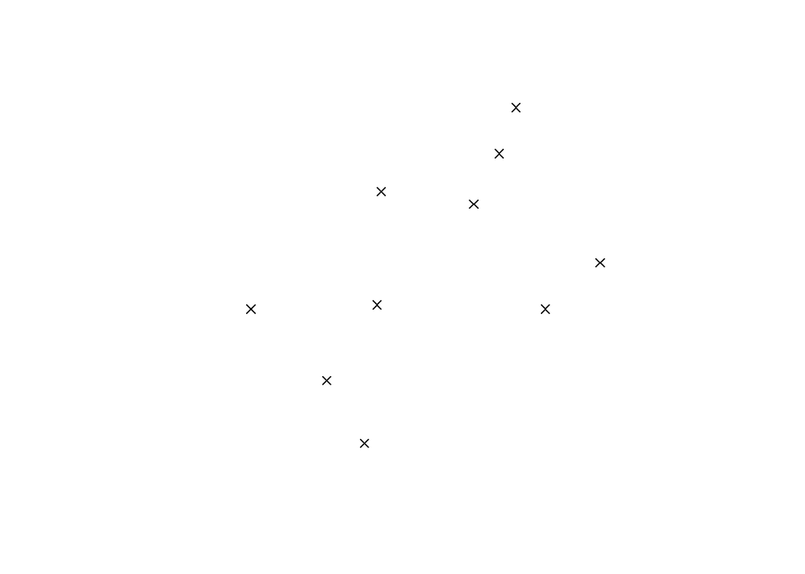

```r
plot(xy.sp, pch = 4)
```

```r
xy.cc = coordinates(xy.sp)
class(xy.cc)
```

```
## [1] "matrix" "array"
```

You can obtain the coordinates and spatial bounding of xy.sp with the functions coordinates() and bbox(), respectively. This type of information can be useful when you are working with polygons created by other people.

```r
coordinates(xy.sp)
```

```
##         xc   yc
##  [1,] 0.61 0.70
##  [2,] 0.39 0.73
##  [3,] 0.91 0.56
##  [4,] 0.35 0.13
##  [5,] 0.78 0.45
##  [6,] 0.26 0.28
##  [7,] 0.67 0.82
##  [8,] 0.38 0.46
##  [9,] 0.71 0.93
## [10,] 0.08 0.45
```

```r
xy.cc = coordinates(xy.sp)#To create a data.frame with the coordinates (it is used a lot in spatial modeling)
class(xy.cc)
```

```
## [1] "matrix" "array"
```

```r
bbox(xy.sp)
```

```
##     min  max
## xc 0.08 0.91
## yc 0.13 0.93
```

We can also create points with attributes (SpatialPointsDataFrame) by building them from a SpatialPoints object (such as xy.sp) and a data.frame containing the attributes.

```r
#To build the data.frame (df) with the attributes
df = data.frame(z1 = round(5 + rnorm(10), 2), z2 = 20:29)
df
```

```
##      z1 z2
## 1  4.10 20
## 2  6.36 21
## 3  3.86 22
## 4  6.31 23
## 5  6.90 24
## 6  5.77 25
## 7  3.77 26
## 8  6.66 27
## 9  4.30 28
## 10 6.05 29
```

```r
#To join the SpatialPoint (x.ysp) to the data.frame (df)
xy.spdf = SpatialPointsDataFrame(xy.sp, df)
xy.spdf
```

```
##     coordinates   z1 z2
## 1   (0.61, 0.7) 4.10 20
## 2  (0.39, 0.73) 6.36 21
## 3  (0.91, 0.56) 3.86 22
## 4  (0.35, 0.13) 6.31 23
## 5  (0.78, 0.45) 6.90 24
## 6  (0.26, 0.28) 5.77 25
## 7  (0.67, 0.82) 3.77 26
## 8  (0.38, 0.46) 6.66 27
## 9  (0.71, 0.93) 4.30 28
## 10 (0.08, 0.45) 6.05 29
```

```r
class(xy.spdf)
```

```
## [1] "SpatialPointsDataFrame"
## attr(,"package")
## [1] "sp"
```

## **Spatial lines**

Spatial lines are retrieved from external sources frequently; however, the following example show how to build an object of class SpatialLines from scratch. We firstly create the points that lines are going to follow. We secondly create the lines using these points and the function Line(). We thirdly put these lines in a list separately; these lines are not spatial object at this point. We finally merge both lines and give spatial properties with the function SpatialLines(). Note that the lines objects must be given character ID values, and that these values must be unique for Lines objects combined in a SpatialLines objects.

```r
# To create the points that the lines follow.
l1 = cbind(c(1,2,3),c(3,2,2))
l1a = cbind(l1[,1]+.05,l1[,2]+.05)
l2 = cbind(c(1,2,3),c(1,1.5,1))

# To create the lines.
Sl1 = Line(l1)
Sl1a = Line(l1a)
Sl2 = Line(l2)

# To put these lines in a list separately.
S1 = Lines(list(Sl1, Sl1a), ID="a")
S2 = Lines(list(Sl2), ID="b")
#
Sl = SpatialLines(list(S1,S2))
summary(Sl)
```

```
## Object of class SpatialLines
## Coordinates:
##   min  max
## x   1 3.05
## y   1 3.05
## Is projected: NA
## proj4string : [NA]
```

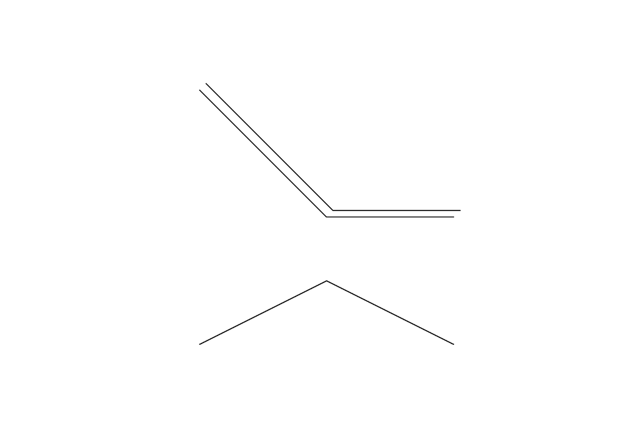

```r
plot(Sl)
```

We can create a SpatialLines object with attributes by attaching an attribute table (data.frame). In the next codes, the function sapply() applies the function slot() to each line object to generate an ID.

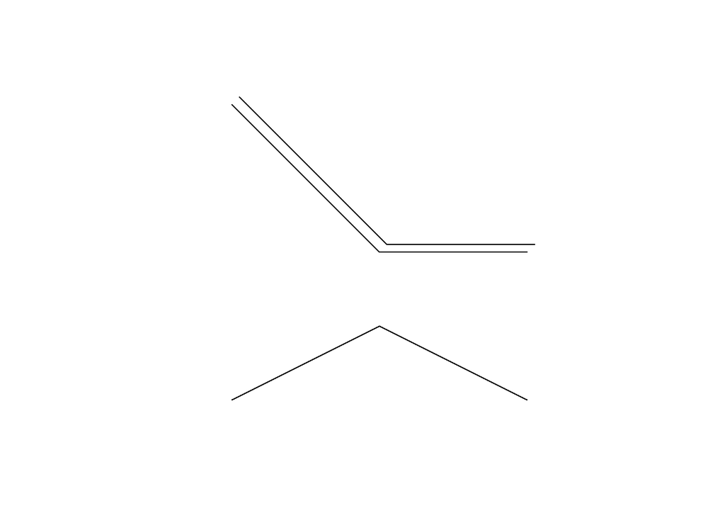

```r
df_2 = data.frame(z = c(1,2), row.names=sapply(slot(Sl, "lines"), function(x) slot(x, "ID")))
Sldf = SpatialLinesDataFrame(Sl, data = df_2)
plot(Sldf)
```

```r
summary(Sldf)
```

```
## Object of class SpatialLinesDataFrame
## Coordinates:
##   min  max
## x   1 3.05
## y   1 3.05
## Is projected: NA
## proj4string : [NA]
## Data attributes:
##        z
##  Min.   :1.00
##  1st Qu.:1.25
##  Median :1.50
##  Mean   :1.50
##  3rd Qu.:1.75
##  Max.   :2.00
```

```r
#To verify ID (a and b) and the structure of Sldf.
str(Sldf)
```

```
## Formal class 'SpatialLinesDataFrame' [package "sp"] with 4 slots
##   ..@ data       :'data.frame':  2 obs. of  1 variable:
##   .. ..$ z: num [1:2] 1 2
##   ..@ lines      :List of 2
##   .. ..$ :Formal class 'Lines' [package "sp"] with 2 slots
##   .. .. .. ..@ Lines:List of 2
##   .. .. .. .. ..$ :Formal class 'Line' [package "sp"] with 1 slot
##   .. .. .. .. .. .. ..@ coords: num [1:3, 1:2] 1 2 3 3 2 2
##   .. .. .. .. ..$ :Formal class 'Line' [package "sp"] with 1 slot
##   .. .. .. .. .. .. ..@ coords: num [1:3, 1:2] 1.05 2.05 3.05 3.05 2.05 2.05
##   .. .. .. ..@ ID   : chr "a"
##   .. ..$ :Formal class 'Lines' [package "sp"] with 2 slots
##   .. .. .. ..@ Lines:List of 1
##   .. .. .. .. ..$ :Formal class 'Line' [package "sp"] with 1 slot
##   .. .. .. .. .. .. ..@ coords: num [1:3, 1:2] 1 2 3 1 1.5 1
##   .. .. .. ..@ ID   : chr "b"
##   ..@ bbox       : num [1:2, 1:2] 1 1 3.05 3.05
##   .. ..- attr(*, "dimnames")=List of 2
##   .. .. ..$ : chr [1:2] "x" "y"
##   .. .. ..$ : chr [1:2] "min" "max"
##   ..@ proj4string:Formal class 'CRS' [package "sp"] with 1 slot
##   .. .. ..@ projargs: chr NA
```

## **Spatial Polygons**

Now we will build polygons from scratch. The function cbind() allows the construction of the points that form the polygons while the function Polygon() creates no-spatial polygons. The argument hole = TRUE of Sr4 is for setting a polygon as hole.

```r
#To create no-spatial polygons
Sr1 = Polygon(cbind(c(2,4,4,1,2),c(2,3,5,4,2)))
Sr2 = Polygon(cbind(c(5,4,2,5),c(2,3,2,2)))
Sr3 = Polygon(cbind(c(4,4,5,10,4),c(5,3,2,5,5)))
Sr4 = Polygon(cbind(c(5,6,6,5,5),c(4,4,3,3,4)), hole = TRUE)
Sr1@coords #To see coordinates
```

```
##      [,1] [,2]
## [1,]    2    2
## [2,]    4    3
## [3,]    4    5
## [4,]    1    4
## [5,]    2    2
```

```r
#To put the polygons in a list and add IDs ("s1","s2","s3").
Srs1 = Polygons(list(Sr1), "s1")
Srs2 = Polygons(list(Sr2), "s2")
Srs3 = Polygons(list(Sr3, Sr4), "s3/s4")
```

Note that the Polygons objects must be given character ID values, and that these values must be unique for Polygons objects combined in a SpatialPolygons object. Now we are going to create the spatial polygon.

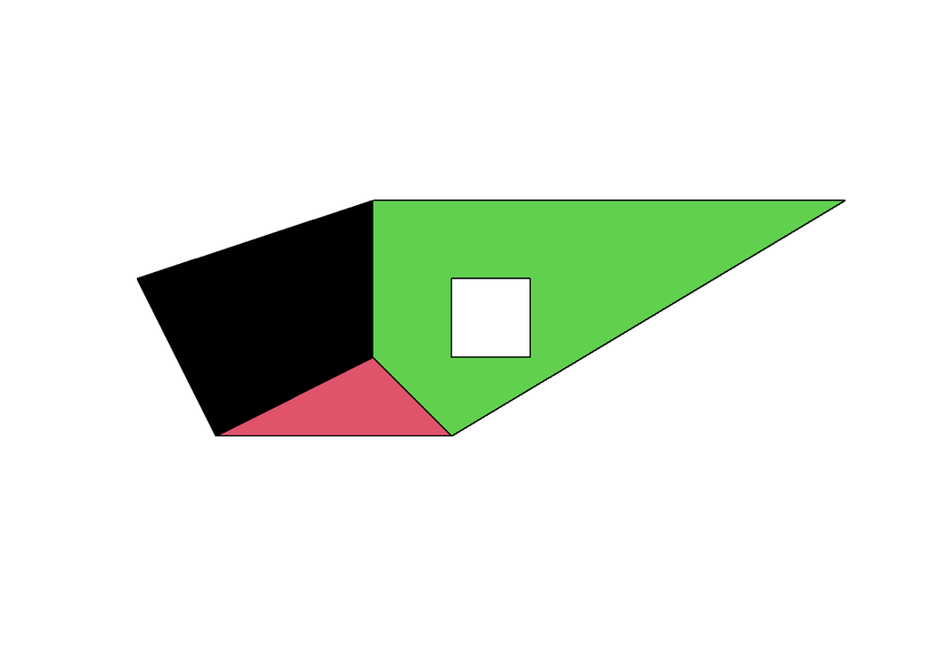

```r
#To create the final spatial polygons and plot it.
SpP = SpatialPolygons(list(Srs1,Srs2,Srs3), 1:3)
plot(SpP, col = 1:3)
```

As we did for spatial point and lines, we can attach attributes to the spatial polygons. Polygons with attributes (objects of class SpatialPolygonsDataFrame) are built from the SpatialPolygons object (topology) and the attributes (data.frame). The row.names of the attributes data frame are matched with the ID slots of the SpatialPolygons object, and the rows of the data frame will be re-ordered if necessary.

```r
attr = data.frame(a=1:3, row.names=c("s3/s4", "s2", "s1"))
attr
```

```
##       a
## s3/s4 1
## s2    2
## s1    3
```

```r
SrDf = SpatialPolygonsDataFrame(SpP, attr)
SrDf
```

```
## An object of class "SpatialPolygonsDataFrame"
## Slot "data":
##       a
## s1    3
## s2    2
## s3/s4 1
##
## Slot "polygons":
## [[1]]
## An object of class "Polygons"
## Slot "Polygons":
## [[1]]
## An object of class "Polygon"
## Slot "labpt":
## [1] 2.696970 3.545455
##
## Slot "area":
## [1] 5.5
##
## Slot "hole":
## [1] FALSE
##
## Slot "ringDir":
## [1] 1
##
## Slot "coords":
##      [,1] [,2]
## [1,]    2    2
## [2,]    1    4
## [3,]    4    5
## [4,]    4    3
## [5,]    2    2
##
##
##
## Slot "plotOrder":
## [1] 1
##
## Slot "labpt":
## [1] 2.696970 3.545455
```

[output cut: 107 more lines]

```
## [1] 10
##
##
##
## Slot "plotOrder":
## [1] 1 2 3
##
## Slot "bbox":
##   min max
## x   1  10
## y   2   5
##
## Slot "proj4string":
## Coordinate Reference System:
## Deprecated Proj.4 representation: NA
```

```r
as(SrDf, "data.frame")
```

```
##       a
## s1    3
## s2    2
## s3/s4 1
```

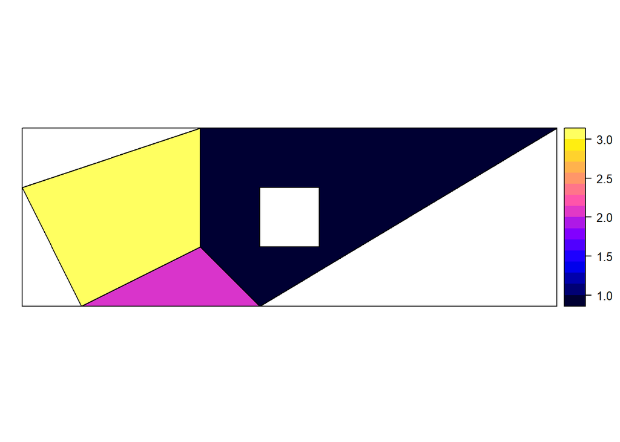

```r
spplot(SrDf)# the function spplot() is a method for plotting spatial data with attributes.
```

# **IV. Creating spatial objects from scratch using sf**

Package sf represents simple features (sf) as native R objects. All functions and methods of sf are prefixed by st_, which means spatial type. As in sp, attributes are typically stored in data.frame objects. However, geometrics are also stored in a data.frame-column in a column at sf (a list of length equal to the number of records in the data.frame).

## **Spatial points**

The function “st_point” creates simple spatial points from a numeric vector, matrix or list. The character-argument “dim” indicates dimensions: “XY”, “XYZ”, “XYM”, or “XYZM”; only really needed for three-dimensional points (which can be either XYZ or XYM).

```r
rm(list = ls(all.names = TRUE))
gc()
```

```
##           used (Mb) gc trigger  (Mb) max used  (Mb)
## Ncells 1378683 73.7    2592478 138.5  2483175 132.7
## Vcells 2404512 18.4    8388608  64.0  3667872  28.0
```

```r
x = st_point(c(1,2))
x
```

```
## POINT (1 2)
```

```r
str(x)
```

```
##  'XY' num [1:2] 1 2
```

```r
#
x2 = st_point(c(1,2,3),dim = "XYZ")
x2
```

```
## POINT Z (1 2 3)
```

```r
str(x2)
```

```
##  'XYZ' num [1:3] 1 2 3
```

```r
#
x3 = st_point(c(1,2,3), dim = "XYM")
x3
```

```
## POINT M (1 2 3)
```

```r
str(x3)
```

```
##  'XYM' num [1:3] 1 2 3
```

```r
#
x4 = st_point(c(1,2,3,4), dim = "XYZM")
x4
```

```
## POINT ZM (1 2 3 4)
```

```r
str(x4)
```

```
##  'XYZM' num [1:4] 1 2 3 4
```

```r
#
plot(x)
```

[output not shown]

```r
#
```

The function ” st_multipoint” creates multiple spatial points from a numeric vector, matrix or list. The function “st_geometry” gets the geometry of the object.

```r
xc = round(runif(10), 2)
yc = round(runif(10), 2)
xy = cbind(xc, yc)
xy
```

```
##         xc   yc
##  [1,] 0.04 0.06
##  [2,] 0.29 0.80
##  [3,] 0.04 0.08
##  [4,] 0.69 0.40
##  [5,] 0.23 0.24
##  [6,] 0.96 0.21
##  [7,] 0.80 0.68
##  [8,] 0.53 0.23
##  [9,] 0.09 0.30
## [10,] 0.05 0.80
```

```r
xy_2 = st_multipoint(xy)
xy_2
```

```
## MULTIPOINT ((0.04 0.06), (0.29 0.8), (0.04 0.08), (0.69 0.4), (0.23 0.24), (0.96 0.21), (0.8 0.68), (0.53 0.23), (0.09 0.3), (0.05 0.8))
```

```r
st_geometry(xy_2)
```

```
## Geometry set for 1 feature
## Geometry type: MULTIPOINT
## Dimension:     XY
## Bounding box:  xmin: 0.04 ymin: 0.06 xmax: 0.96 ymax: 0.8
## CRS:           NA
```

```
## MULTIPOINT ((0.04 0.06), (0.29 0.8), (0.04 0.08...
```

```r
str(xy_2)
```

```
##  'XY' num [1:10, 1:2] 0.04 0.29 0.04 0.69 0.23 0.96 0.8 0.53 0.09 0.05 ...
##  - attr(*, "dimnames")=List of 2
##   ..$ : NULL
##   ..$ : chr [1:2] "xc" "yc"
```

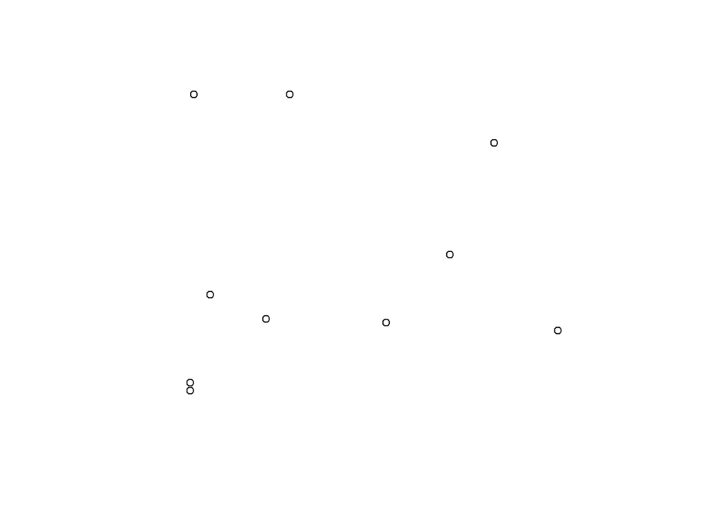

```r
plot(xy_2)
```

You can obtain the coordinates with the functions st_coordinates(); however, we cannot obtain the spatial bounding of xy.cc because it is a “matrix” with not strict spatial properties.

```r
xy.cc = st_coordinates(xy_2)
class(xy.cc)
```

```
## [1] "matrix" "array"
```

```r
xy.cc
```

```
##          X    Y L1
##  [1,] 0.04 0.06  1
##  [2,] 0.29 0.80  1
##  [3,] 0.04 0.08  1
##  [4,] 0.69 0.40  1
##  [5,] 0.23 0.24  1
##  [6,] 0.96 0.21  1
##  [7,] 0.80 0.68  1
##  [8,] 0.53 0.23  1
##  [9,] 0.09 0.30  1
## [10,] 0.05 0.80  1
```

```r
xy.cc[,c(1,2)]
```

```
##          X    Y
##  [1,] 0.04 0.06
##  [2,] 0.29 0.80
##  [3,] 0.04 0.08
##  [4,] 0.69 0.40
##  [5,] 0.23 0.24
##  [6,] 0.96 0.21
##  [7,] 0.80 0.68
##  [8,] 0.53 0.23
##  [9,] 0.09 0.30
## [10,] 0.05 0.80
```

```r
st_bbox(xy.cc)
```

```
## xmin ymin xmax ymax
##   NA   NA   NA   NA
```

So, we need to convert the st object to sf object (which has spatial properties; do you remember this process in sp?) applying the function st_as_sf().

```r
xy_2 = data.frame(xy)
xy.sp_2 = sf::st_as_sf(xy_2, coords = c("xc","yc"))
xy.sp_2
```

```
## Simple feature collection with 10 features and 0 fields
## Geometry type: POINT
## Dimension:     XY
## Bounding box:  xmin: 0.04 ymin: 0.06 xmax: 0.96 ymax: 0.8
## CRS:           NA
##             geometry
## 1  POINT (0.04 0.06)
## 2   POINT (0.29 0.8)
## 3  POINT (0.04 0.08)
## 4   POINT (0.69 0.4)
## 5  POINT (0.23 0.24)
## 6  POINT (0.96 0.21)
## 7   POINT (0.8 0.68)
## 8  POINT (0.53 0.23)
## 9   POINT (0.09 0.3)
## 10  POINT (0.05 0.8)
```

```r
xy.cc_2 = st_coordinates(xy.sp_2)
st_coordinates(xy.sp_2)
```

```
##          X    Y
##  [1,] 0.04 0.06
##  [2,] 0.29 0.80
##  [3,] 0.04 0.08
##  [4,] 0.69 0.40
##  [5,] 0.23 0.24
##  [6,] 0.96 0.21
##  [7,] 0.80 0.68
##  [8,] 0.53 0.23
##  [9,] 0.09 0.30
## [10,] 0.05 0.80
```

```r
st_bbox(xy.sp_2)
```

```
## xmin ymin xmax ymax
## 0.04 0.06 0.96 0.80
```

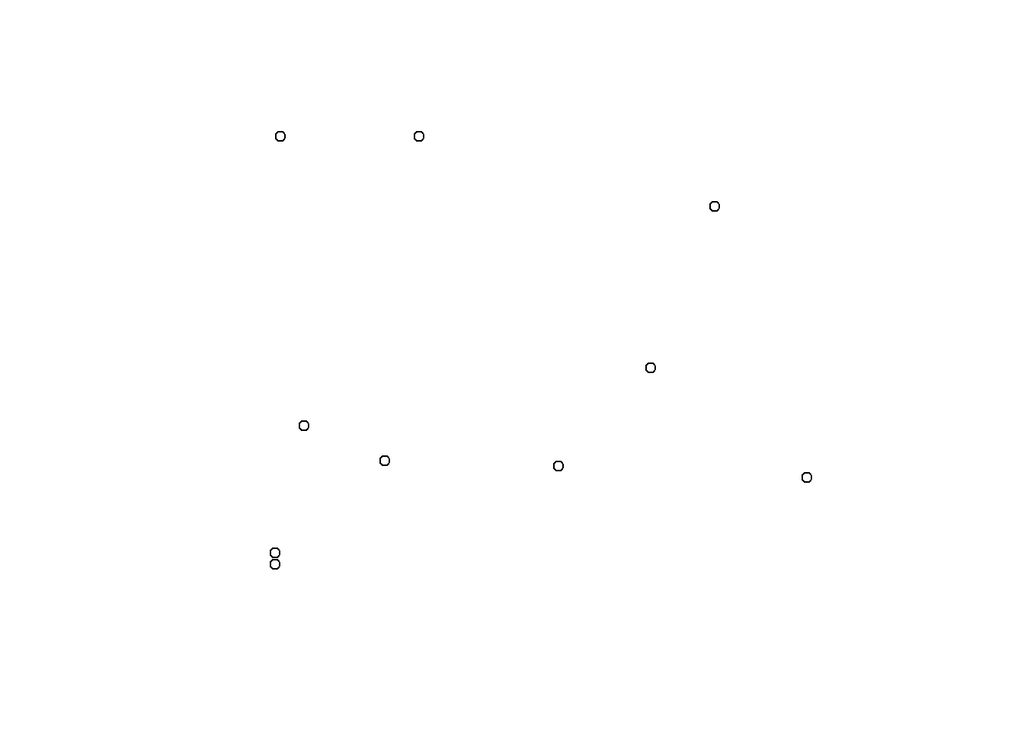

```r
plot(xy.sp_2)
```

We can add attributes by adding vectors as columns.

```r
df = data.frame(z1 = round(5 + rnorm(10), 2), z2 = 20:29)
df
```

```
##      z1 z2
## 1  7.06 20
## 2  6.33 21
## 3  5.38 22
## 4  3.55 23
## 5  3.78 24
## 6  5.37 25
## 7  6.32 26
## 8  5.92 27
## 9  6.93 28
## 10 4.03 29
```

```r
#
xy.sp_2$z1 = df$z1
xy.sp_2$z2 = df$z2
xy.sp_2
```

```
## Simple feature collection with 10 features and 2 fields
## Geometry type: POINT
## Dimension:     XY
## Bounding box:  xmin: 0.04 ymin: 0.06 xmax: 0.96 ymax: 0.8
## CRS:           NA
##             geometry   z1 z2
## 1  POINT (0.04 0.06) 7.06 20
## 2   POINT (0.29 0.8) 6.33 21
## 3  POINT (0.04 0.08) 5.38 22
## 4   POINT (0.69 0.4) 3.55 23
## 5  POINT (0.23 0.24) 3.78 24
## 6  POINT (0.96 0.21) 5.37 25
## 7   POINT (0.8 0.68) 6.32 26
## 8  POINT (0.53 0.23) 5.92 27
## 9   POINT (0.09 0.3) 6.93 28
## 10  POINT (0.05 0.8) 4.03 29
```

```r
names(xy.sp_2)
```

```
## [1] "geometry" "z1"       "z2"
```

```r
class(xy.sp_2)
```

```
## [1] "sf"         "data.frame"
```

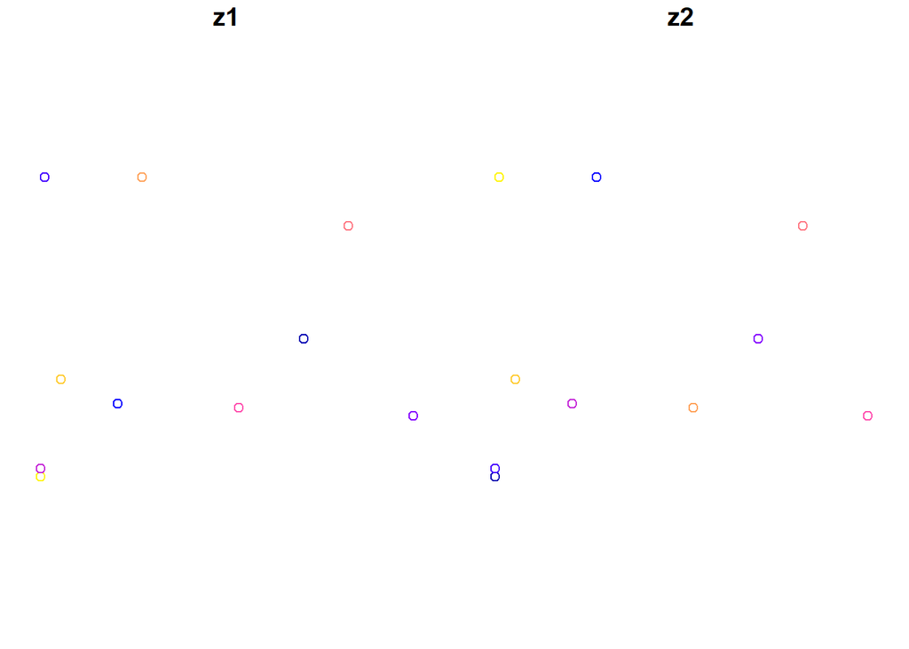

```r
plot(xy.sp_2)
```

**Spatial lines**

Spatial lines can be built using the function st_linestring(). We firstly create the points that lines are going to follow. We secondly create the lines using these points and the function st_linestring(). When you apply this function, the created object (class: “LINESTRING-sfg”) has complete spatial properties; you can check it out by the use of the function st_coordinates(), st_bbox(), and plot(). These objects obviously do not have a CRS.

```r
#pts1 = matrix(1:10, , 2)
pts1 = matrix(1:10, nrow = 5, byrow = F)
pts1
```

```
##      [,1] [,2]
## [1,]    1    6
## [2,]    2    7
## [3,]    3    8
## [4,]    4    9
## [5,]    5   10
```

```r
ls1 = st_linestring(pts1)
ls1
```

```
## LINESTRING (1 6, 2 7, 3 8, 4 9, 5 10)
```

```r
class(ls1)
```

```
## [1] "XY"         "LINESTRING" "sfg"
```

```r
st_coordinates(ls1)
```

```
##      X  Y L1
## [1,] 1  6  1
## [2,] 2  7  1
## [3,] 3  8  1
## [4,] 4  9  1
## [5,] 5 10  1
```

```r
st_bbox(ls1)
```

```
## xmin ymin xmax ymax
##    1    6    5   10
```

```r
plot(ls1)
```

[output not shown]

```r
#pts2 = matrix(1:15, , 3)
pts2 = matrix(1:15, nrow = 5, byrow = F)
ls2 = st_linestring(pts2)
ls2
```

```
## LINESTRING Z (1 6 11, 2 7 12, 3 8 13, 4 9 14, 5 10 15)
```

```r
class(ls2)
```

```
## [1] "XYZ"        "LINESTRING" "sfg"
```

```r
st_coordinates(ls2)
```

```
##      X  Y  Z L1
## [1,] 1  6 11  1
## [2,] 2  7 12  1
## [3,] 3  8 13  1
## [4,] 4  9 14  1
## [5,] 5 10 15  1
```

```r
st_bbox(ls2)
```

```
## xmin ymin xmax ymax
##    1    6    5   10
```

```r
#plot(ls2)#You get an error.

#
#pts3 = matrix(1:15, , 3)
pts3 = matrix(1:15, nrow = 5, byrow = F)
ls3 = st_linestring(pts3, "XYM")
ls3
```

```
## LINESTRING M (1 6 11, 2 7 12, 3 8 13, 4 9 14, 5 10 15)
```

```r
class(ls3)
```

```
## [1] "XYM"        "LINESTRING" "sfg"
```

```r
ls3 = st_zm(ls3, drop == "M")
st_coordinates(ls3)
```

```
##      X  Y L1
## [1,] 1  6  1
## [2,] 2  7  1
## [3,] 3  8  1
## [4,] 4  9  1
## [5,] 5 10  1
```

```r
st_bbox(ls3)
```

```
## xmin ymin xmax ymax
##    1    6    5   10
```

```r
plot(ls3)
```

[output not shown]

How many columns did you eliminate after apply the argument drop == “M” of the function st_zm()? What do you believe when you compare the drop == “M” of the previous chunk.

```r
#pts4 = matrix(1:20, , 4)
pts4 = matrix(1:20, nrow = 5, byrow = F)
ls4 = st_linestring(pts4)
ls4
```

```
## LINESTRING ZM (1 6 11 16, 2 7 12 17, 3 8 13 18, 4 9 14 19, 5 10 15 20)
```

```r
class(ls4)
```

```
## [1] "XYZM"       "LINESTRING" "sfg"
```

```r
#plot(ls4)
ls4 = st_zm(ls4, drop == "M")
ls4
```

```
## LINESTRING (1 6, 2 7, 3 8, 4 9, 5 10)
```

```r
st_coordinates(ls4)
```

```
##      X  Y L1
## [1,] 1  6  1
## [2,] 2  7  1
## [3,] 3  8  1
## [4,] 4  9  1
## [5,] 5 10  1
```

```r
st_bbox(ls4)
```

```
## xmin ymin xmax ymax
##    1    6    5   10
```

```r
plot(ls4)
```

[output not shown]

Spatial polygons also can be create using the function st_polygon (). We firstly create matrices that refer to the points (X,Y) that polygons are going to follow. We later create a list with these matrices to apply the function st_polygon(). The created object (class “XY-POLYGON-sfg”) has complete spatial properties; you can check it out by the use of the function st_coordinates(), st_bbox(), and plot(). Again, this object obviously does not have a CRS.

```r
outer = matrix(c(0,0,10,0,10,10,0,10,0,0),ncol=2, byrow=TRUE)
hole1 = matrix(c(1,1,1,2,2,2,2,1,1,1),ncol=2, byrow=TRUE)
hole2 = matrix(c(5,5,5,6,6,6,6,5,5,5),ncol=2, byrow=TRUE)
pts4 = list(outer, hole1, hole2)
str(pts4)
```

```
## List of 3
##  $ : num [1:5, 1:2] 0 10 10 0 0 0 0 10 10 0
##  $ : num [1:5, 1:2] 1 1 2 2 1 1 2 2 1 1
##  $ : num [1:5, 1:2] 5 5 6 6 5 5 6 6 5 5
```

```r
pl1 = st_polygon(pts4)
pl1
```

```
## POLYGON ((0 0, 10 0, 10 10, 0 10, 0 0), (1 1, 1 2, 2 2, 2 1, 1 1), (5 5, 5 6, 6 6, 6 5, 5 5))
```

```r
class(pl1)
```

```
## [1] "XY"      "POLYGON" "sfg"
```

```r
str(pl1)
```

```
## List of 3
##  $ : num [1:5, 1:2] 0 10 10 0 0 0 0 10 10 0
##  $ : num [1:5, 1:2] 1 1 2 2 1 1 2 2 1 1
##  $ : num [1:5, 1:2] 5 5 6 6 5 5 6 6 5 5
##  - attr(*, "class")= chr [1:3] "XY" "POLYGON" "sfg"
```

```r
st_coordinates(pl1)
```

```
##        X  Y L1 L2
##  [1,]  0  0  1  1
##  [2,] 10  0  1  1
##  [3,] 10 10  1  1
##  [4,]  0 10  1  1
##  [5,]  0  0  1  1
##  [6,]  1  1  2  1
##  [7,]  1  2  2  1
##  [8,]  2  2  2  1
##  [9,]  2  1  2  1
## [10,]  1  1  2  1
## [11,]  5  5  3  1
## [12,]  5  6  3  1
## [13,]  6  6  3  1
## [14,]  6  5  3  1
## [15,]  5  5  3  1
```

```r
st_bbox(pl1 )
```

```
## xmin ymin xmax ymax
##    0    0   10   10
```

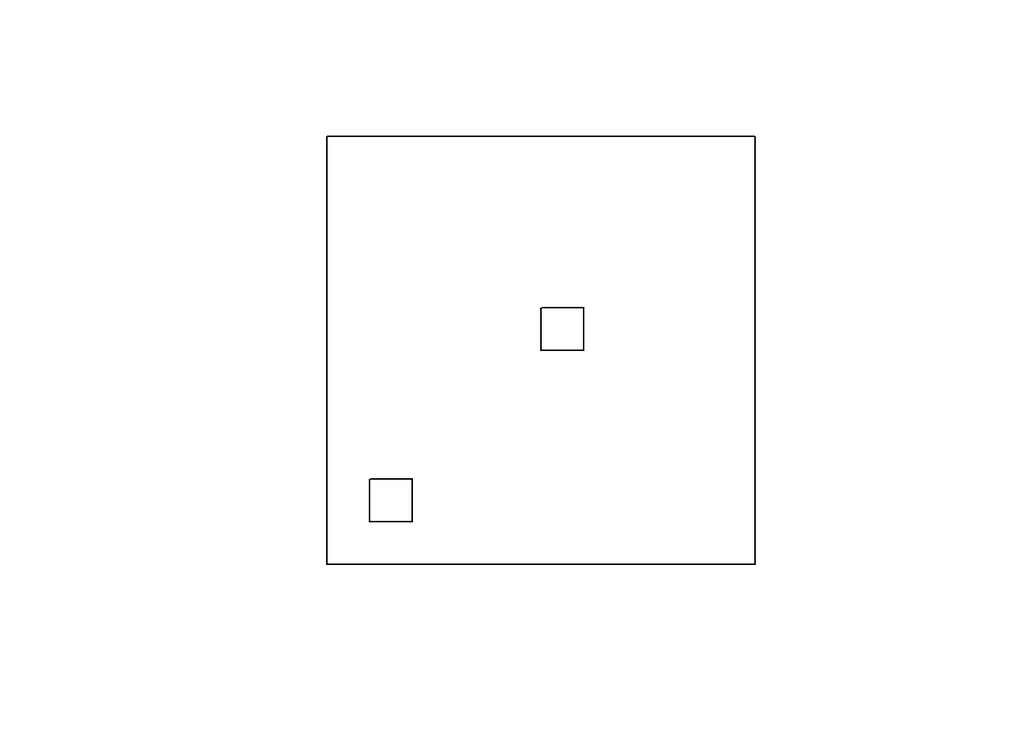

```r
plot(pl1 )
```

# **V. Loading and operating existing shapefiles into R**

The data required to visualize a single shapefile in Arc or QGIS is split into many files (e.g., cpg, .dbf, .prj, etc.), the most known of which is the sacred .shp file (do you know the function of the other files?). To get all this info into an organized spatial object in R is easy, and in fact, as is often the case in R, there are multiple packages and functions that will do this for you. Here are three of the most used options to read .shp of the packages raster and sf:

```r
library(sf)
DEPARTMENTS_1 = st_read("MGN_DPTO_POLITICO.shp")
DEPARTMENTS_1
```

```
## Simple feature collection with 33 features and 10 fields
## Geometry type: MULTIPOLYGON
## Dimension:     XY
## Bounding box:  xmin: -81.73562 ymin: -4.229406 xmax: -66.84722 ymax: 13.39473
## Geodetic CRS:  WGS 84
## First 10 features:
##    DPTO_CCDGO DPTO_CNMBR DPTO_ANO_C
## 1          05  ANTIOQUIA       1886
## 2          23    CÓRDOBA       1951
## 3          27      CHOCÓ       1947
## 4          70      SUCRE       1966
## 5          08  ATLÁNTICO       1910
## 6          13    BOLÍVAR       1886
## 7          47  MAGDALENA       1964
## 8          20      CESAR       1967
```

[output cut: 24 more lines]

```r
library(terra)
DEPARTMENTS_3 = vect("MGN_DPTO_POLITICO.shp")

library(raster)
DEPARTMENTS_2 = shapefile("MGN_DPTO_POLITICO.shp")
```

[output not shown]

We are going to evaluate the vector spatial feature read by the function “st_read” since it is the update of r to use from now. You can run some functions to do an evaluation of this “sf-data.frame” object.

```r
class(DEPARTMENTS_1)
```

```
## [1] "sf"         "data.frame"
```

```r
names(DEPARTMENTS_1)
```

```
##  [1] "DPTO_CCDGO" "DPTO_CNMBR" "DPTO_ANO_C" "DPTO_ACT_A" "DPTO_NAREA"
##  [6] "DPTO_CSMBL" "DPTO_VGNC"  "SHAPE_AREA" "SHAPE_LEN"  "AREA"
## [11] "geometry"
```

```r
head(DEPARTMENTS_1)
```

```
## Simple feature collection with 6 features and 10 fields
## Geometry type: MULTIPOLYGON
## Dimension:     XY
## Bounding box:  xmin: -77.88378 ymin: 3.964883 xmax: -73.74578 ymax: 11.10537
## Geodetic CRS:  WGS 84
##   DPTO_CCDGO DPTO_CNMBR DPTO_ANO_C                        DPTO_ACT_A DPTO_NAREA
## 1         05  ANTIOQUIA       1886     Constitucion Politica de 1886   62804.71
## 2         23    CÓRDOBA       1951 Ley 9 del 18 de Diciembre de 1951   25086.55
## 3         27      CHOCÓ       1947 Ley 13 del 3 de Noviembre de 1947   48353.22
## 4         70      SUCRE       1966    Ley 47 del 8 de Agosto de 1966   10591.85
## 5         08  ATLÁNTICO       1910                    Ley 21 de 1910    3313.81
## 6         13    BOLÍVAR       1886     Constitucion Politica de 1886   26719.21
##   DPTO_CSMBL DPTO_VGNC SHAPE_AREA SHAPE_LEN AREA                       geometry
## 1          3      2020  5.1349154 21.443794   NA MULTIPOLYGON (((-76.41355 8...
## 2          3      2020  2.0575332  9.691516   NA MULTIPOLYGON (((-75.91797 9...
## 3          3      2020  3.9397431 20.634463   NA MULTIPOLYGON (((-77.36821 8...
## 4          3      2020  0.8708103  8.570869   NA MULTIPOLYGON (((-75.5232 10...
## 5          3      2020  0.2737698  2.544651   NA MULTIPOLYGON (((-74.84946 1...
## 6          3      2020  2.1955769 16.234817   NA MULTIPOLYGON (((-75.25555 1...
```

```r
str(DEPARTMENTS_1)
```

```
## Classes 'sf' and 'data.frame':   33 obs. of  11 variables:
##  $ DPTO_CCDGO: chr  "05" "23" "27" "70" ...
##  $ DPTO_CNMBR: chr  "ANTIOQUIA" "CÓRDOBA" "CHOCÓ" "SUCRE" ...
##  $ DPTO_ANO_C: num  1886 1951 1947 1966 1910 ...
##  $ DPTO_ACT_A: chr  "Constitucion Politica de 1886" "Ley 9 del 18 de Diciembre de 1951" "Ley 13 del 3 de Noviembre de 1947" "Ley 47 del 8 de Agosto de 1966" ...
##  $ DPTO_NAREA: num  62805 25087 48353 10592 3314 ...
##  $ DPTO_CSMBL: chr  "3" "3" "3" "3" ...
##  $ DPTO_VGNC : num  2020 2020 2020 2020 2020 2020 2020 2020 2020 2020 ...
##  $ SHAPE_AREA: num  5.135 2.058 3.94 0.871 0.274 ...
##  $ SHAPE_LEN : num  21.44 9.69 20.63 8.57 2.54 ...
##  $ AREA      : num  NA NA NA NA NA NA NA NA NA NA ...
##  $ geometry  :sfc_MULTIPOLYGON of length 33; first list element: List of 1
##   ..$ :List of 1
##   .. ..$ : num [1:39008, 1:2] -76.4 -76.4 -76.4 -76.4 -76.4 ...
##   ..- attr(*, "class")= chr [1:3] "XY" "MULTIPOLYGON" "sfg"
##  - attr(*, "sf_column")= chr "geometry"
##  - attr(*, "agr")= Factor w/ 3 levels "constant","aggregate",..: NA NA NA NA NA NA NA NA NA NA
##   ..- attr(*, "names")= chr [1:10] "DPTO_CCDGO" "DPTO_CNMBR" "DPTO_ANO_C" "DPTO_ACT_A" ...
```

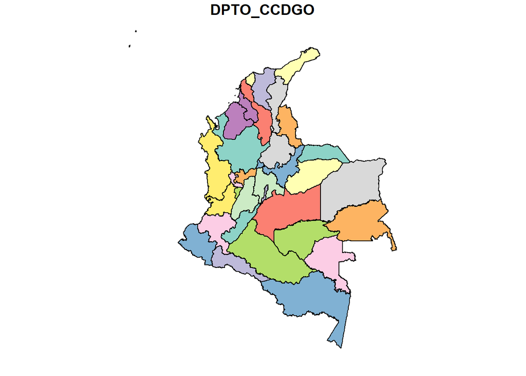

```r
plot(DEPARTMENTS_1[1])
```

You can access the geometry of this “sf-data.frame” object applying different methods, as well as, you can get one of the departments (the department corresponding to the first row) as a traditional “data.frame” object. Try to get the department of the 20th row.

```r
class(DEPARTMENTS_1$geom)#it is a list of class sfc
```

```
## [1] "sfc_MULTIPOLYGON" "sfc"
```

```r
str(DEPARTMENTS_1$geom)
```

```
## sfc_MULTIPOLYGON of length 33; first list element: List of 1
##  $ :List of 1
##   ..$ : num [1:39008, 1:2] -76.4 -76.4 -76.4 -76.4 -76.4 ...
##  - attr(*, "class")= chr [1:3] "XY" "MULTIPOLYGON" "sfg"
```

```r
DEPARTMENTS_1$geometry[1]
```

```
## Geometry set for 1 feature
## Geometry type: MULTIPOLYGON
## Dimension:     XY
## Bounding box:  xmin: -77.12783 ymin: 5.418558 xmax: -73.88128 ymax: 8.873974
## Geodetic CRS:  WGS 84
```

```
## MULTIPOLYGON (((-76.41355 8.873829, -76.40465 8...
```

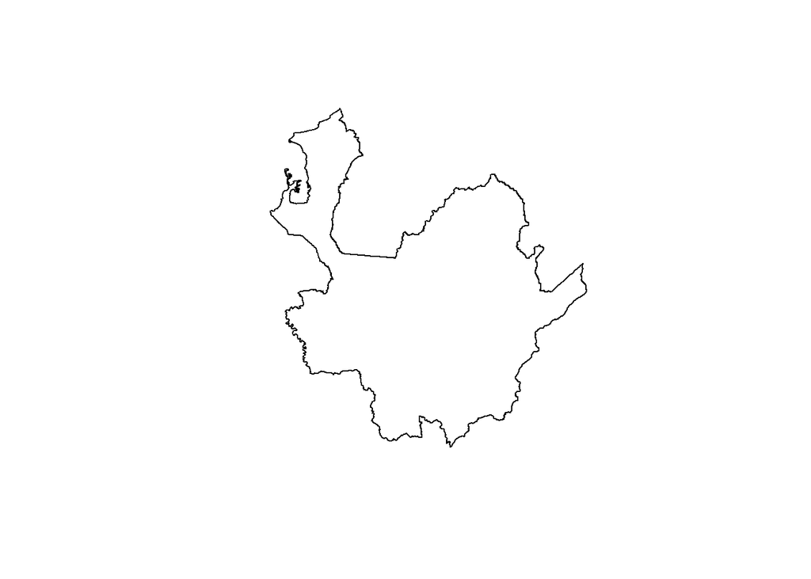

```r
plot(DEPARTMENTS_1$geometry[1])
```